# Johns Hopkins - Practical Machine Learning Course Project

Benjamin Berhault

September 27, 2015

Using devices such as Jawbone Up, Nike FuelBand, and Fitbit it is now possible to collect a large amount of data about personal activity relatively inexpensively. These type of devices are part of the quantified self movement - a group of enthusiasts who take measurements about themselves regularly to improve their health, to find patterns in their behavior, or because they are tech geeks. One thing that people regularly do is quantify how much of a particular activity they do, but they rarely quantify how well they do it. In this project, your goal will be to use data from accelerometers on the belt, forearm, arm, and dumbell of 6 participants. They were asked to perform barbell lifts correctly and incorrectly in 5 different ways. More information is available from the website here: http://groupware.les.inf.puc-rio.br/har (see the section on the Weight Lifting Exercise Dataset).

#### Mission

The goal of your project is to predict the manner in which they did the exercise in regard to 5 different classes (A, B, C, D, E) point by the “classe” variable in the training set.

- You should create a report describing how you built your model, how you used cross validation, For that purpose we will use the rpart.control() from rpart package and trainControl() from the Caret package. (http://machinelearningmastery.com/how-to-estimate-model-accuracy-in-r-using-the-caret-package/)

*Quick review : The k-fold cross validation method involves splitting the dataset into k-subsets. For each subset is held out while the model is trained on all other subsets. This process is completed until accuracy is determine for each instance in the dataset, and an overall accuracy estimate is provided.*

- What you think the expected out of sample error is, and why you made the choices you did.
- You will also use your prediction model to predict 20 different test cases.

#### URL

- [Coursera - Johns Hopkins : Practical Machine Learning](https://www.coursera.org/course/predmachlearn)
- Code source can be found here : github.com/benjamin-berhault/practical-machine-learning

#### Data :

- [Training data](https://d396qusza40orc.cloudfront.net/predmachlearn/pml-training.csv)
- [Test data](https://d396qusza40orc.cloudfront.net/predmachlearn/pml-testing.csv)

## Libraries

```r
library(caret)
library(rattle)
library(rpart)
library(rpart.plot)
library(RColorBrewer)
library(randomForest)
library(gbm)
```

## 1. Data loading

```r
trainURL <-"https://d396qusza40orc.cloudfront.net/predmachlearn/pml-training.csv"
testURL <- "https://d396qusza40orc.cloudfront.net/predmachlearn/pml-testing.csv"
trainingFile <- "./pml-training.csv"
testingFile  <- "./pml-testing.csv"
if (!file.exists(trainingFile)) {download.file(trainURL, destfile=trainingFile)}
if (!file.exists(testingFile)) {download.file(testURL, destfile=testingFile)}

# training set
training <- read.csv("pml-training.csv", na.strings=c("NA","#DIV/0!",""))
# testing set
testing <- read.csv("pml-testing.csv", na.strings=c("NA","#DIV/0!",""))
```

## 2. Data preprocessing

We begin by removing Near Zero Variance variables

**nearZeroVar()** ([doc.](http://www.inside-r.org/packages/cran/caret/docs/nearZeroVar)) : with this function by default, a predictor is classified as near-zero variance if the percentage of unique values in the samples is less than 10% and when the frequency ratio mentioned above is greater than 19 (95/5).

```r
# nzv : collect column near zero variance info
nzv <- nearZeroVar(training, saveMetrics=TRUE)
# save those column names
non_relevant_columns <- c(names(training[,nzv$nzv==TRUE]))
# delete those columns
training <- training[,nzv$nzv==FALSE]
```

We remove the ID column that is non relevant for the analysis.

```r
non_relevant_columns <- c(non_relevant_columns,names(training[1]))
training <- training[c(-1)]
```

We investigate missing values

```r
# Quantity of NAs by column
training_nb_of_NAs <- apply(training, 2, function(x) sum(is.na(x)))

# We check the different amount of missing observations
training_dif_amount_of_NAs <- unique(training_nb_of_NAs)
pourcent_miss_obs <- round(training_dif_amount_of_NAs/nrow(training)*100,2)
pourcent_miss_obs[order(pourcent_miss_obs)]
```

```
##  [1]  0.00 97.93 97.94 97.94 97.95 97.96 97.98 97.98 97.99 98.09 98.32
## [12] 98.33 98.34 98.35 98.36 98.36
```

```r
# Smallest amount of missing observations
pourcent_miss_obs[order(pourcent_miss_obs)][2]
```

```
## [1] 97.93
```

The pourcentage is so important that we remove each column with missing values.

```r
columns_2_ignore <- c()
# columns to ignore
column_with_NA <- (training_nb_of_NAs != 0)
for (i in 1:length(column_with_NA)) {
  if (column_with_NA[i] == TRUE){
    # store the name of column to remove
    columns_2_ignore <- c(columns_2_ignore, names(column_with_NA[i]))
  }
}

# store the name of irrelevant columns
non_relevant_columns <- c(non_relevant_columns,columns_2_ignore)

# remove irrelevant columns from the training dataset
training <- training[, !(colnames(training) %in% columns_2_ignore), drop=FALSE]
```

## 3. Split the dataset

Split the intitial training dataset into two parts : *pre-training* set and *validation* set.

We use the function **“createDataPartition()”** (from the Caret package) to have balanced splits of the data.

```r
set.seed(1982)
inTrain <- createDataPartition(training$classe, p=0.6, list=FALSE)
pre_training <- training[inTrain, ]
validation_set <- training[-inTrain, ]

# pre-training dataset's dimensions
dim(pre_training)
```

```
## [1] 11776    58
```

```r
# validation dataset's dimensions
dim(validation_set)
```

```
## [1] 7846   58
```

Reduce the testing dataset to relevant columns

```r
clean2 <- colnames(pre_training[, -58])  # remove the classe column
testing <- testing[clean2]

# testing dataset's dimensions
dim(testing)
```

```
## [1] 20 57
```

## 4. Test 3 different predictive models

- Decision Tree
- Random Forests
- Generalized Boosted Regression

### Decision Tree

```r
set.seed(1982)
# xval : define the number of cross-validations
fitControl1 = rpart.control(cp = 0, xval = 5)
mod_decisionTree <- rpart(classe ~ ., data=pre_training, method="class", control = fitControl1)
# fancyRpartPlot(mod_decisionTree)
prediction_DT <- predict(mod_decisionTree, validation_set, type = "class")
cmtree <- confusionMatrix(prediction_DT, validation_set$classe)
cmtree
```

```
## Confusion Matrix and Statistics
##
##           Reference
## Prediction    A    B    C    D    E
##          A 2222    5    0    0    0
##          B    9 1481   44    0    3
##          C    1   24 1311   13    1
##          D    0    8   12 1267   23
##          E    0    0    1    6 1415
##
## Overall Statistics
##
##                Accuracy : 0.9809
##                  95% CI : (0.9776, 0.9838)
##     No Information Rate : 0.2845
##     P-Value [Acc > NIR] : < 0.00000000000000022
##
##                   Kappa : 0.9758
##  Mcnemar's Test P-Value : NA
##
## Statistics by Class:
##
##                      Class: A Class: B Class: C Class: D Class: E
## Sensitivity            0.9955   0.9756   0.9583   0.9852   0.9813
## Specificity            0.9991   0.9912   0.9940   0.9934   0.9989
## Pos Pred Value         0.9978   0.9636   0.9711   0.9672   0.9951
## Neg Pred Value         0.9982   0.9941   0.9912   0.9971   0.9958
## Prevalence             0.2845   0.1935   0.1744   0.1639   0.1838
## Detection Rate         0.2832   0.1888   0.1671   0.1615   0.1803
## Detection Prevalence   0.2838   0.1959   0.1721   0.1670   0.1812
## Balanced Accuracy      0.9973   0.9834   0.9762   0.9893   0.9901
```

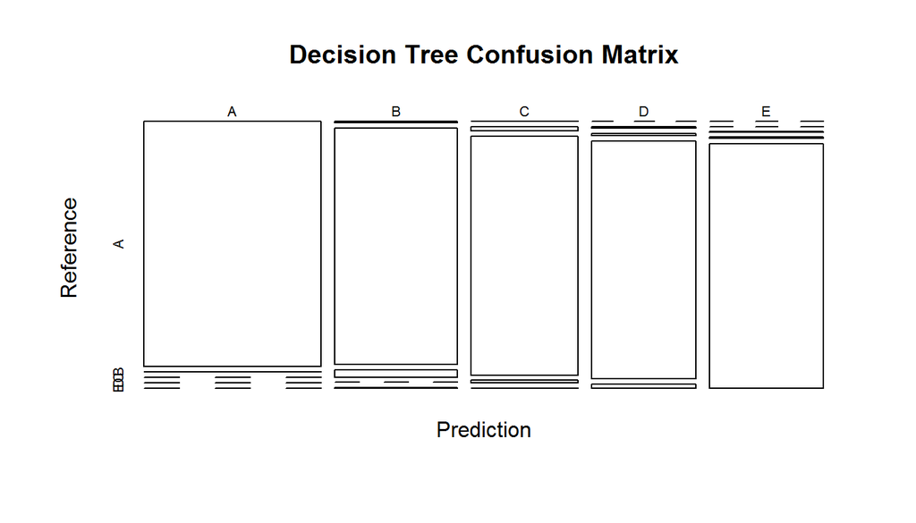

```r
par(mfrow=c(1,1))
plot(cmtree$table, col = cmtree$byClass, main = paste("Decision Tree Confusion Matrix"))
```

With “Decision Tree” method, the prediction reach an accuracy rate of **98.09**%.

### Random Forests

```r
set.seed(1982)

mod_randomForest <- randomForest(classe ~ ., data=pre_training)
prediction_RF <- predict(mod_randomForest, validation_set, type = "class")
cmrf <- confusionMatrix(prediction_RF, validation_set$classe)
cmrf
```

```
## Confusion Matrix and Statistics
##
##           Reference
## Prediction    A    B    C    D    E
##          A 2230    6    0    0    0
##          B    2 1511    2    0    0
##          C    0    1 1365    5    0
##          D    0    0    1 1281    3
##          E    0    0    0    0 1439
##
## Overall Statistics
##
##                Accuracy : 0.9975
##                  95% CI : (0.9961, 0.9984)
##     No Information Rate : 0.2845
##     P-Value [Acc > NIR] : < 0.00000000000000022
##
##                   Kappa : 0.9968
##  Mcnemar's Test P-Value : NA
##
## Statistics by Class:
##
##                      Class: A Class: B Class: C Class: D Class: E
## Sensitivity            0.9991   0.9954   0.9978   0.9961   0.9979
## Specificity            0.9989   0.9994   0.9991   0.9994   1.0000
## Pos Pred Value         0.9973   0.9974   0.9956   0.9969   1.0000
## Neg Pred Value         0.9996   0.9989   0.9995   0.9992   0.9995
## Prevalence             0.2845   0.1935   0.1744   0.1639   0.1838
## Detection Rate         0.2842   0.1926   0.1740   0.1633   0.1834
## Detection Prevalence   0.2850   0.1931   0.1747   0.1638   0.1834
## Balanced Accuracy      0.9990   0.9974   0.9984   0.9978   0.9990
```

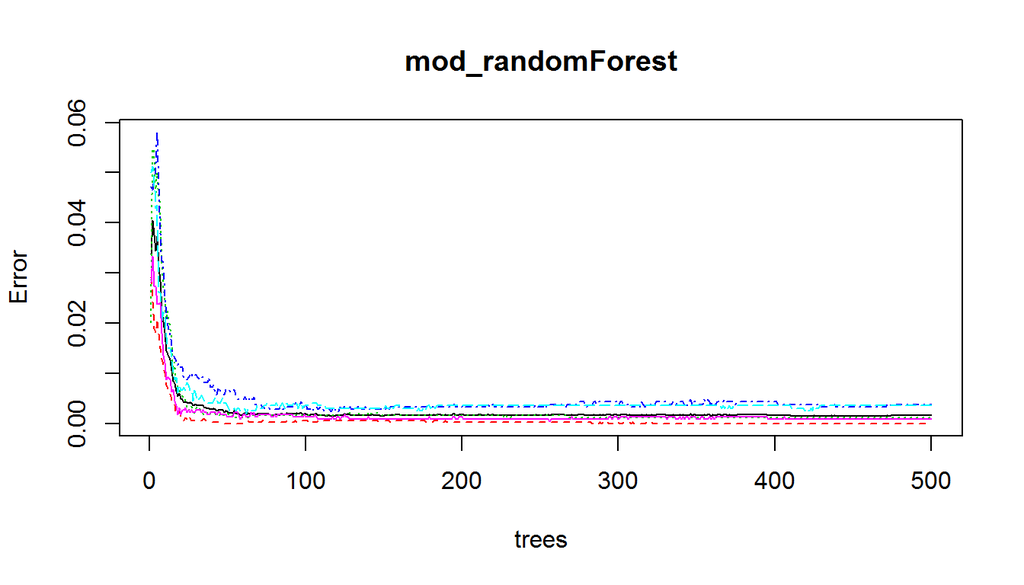

```r
par(mfrow=c(1,1))
plot(mod_randomForest)
```

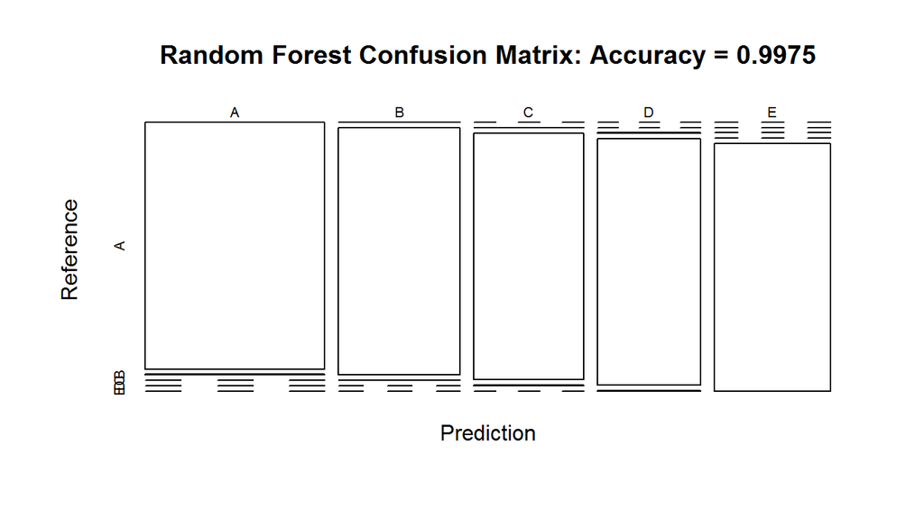

```r
plot(cmrf$table, col = cmtree$byClass, main = paste("Random Forest Confusion Matrix: Accuracy =", round(cmrf$overall['Accuracy'], 4)))
```

With “Random Forests” method, the prediction reach an accuracy rate of **99.75**%.

### Generalized Boosted Regression

```r
set.seed(1982)
# method : cross validation resampling method | number : number of resampling iterations
fitControl2 <- trainControl(method = "cv",
                           number = 5)

# method : Generalized Boosted Regression Model
mod_gradientBoostR <- train(classe ~ ., data=pre_training, method = "gbm",
                 trControl = fitControl2,
                 verbose = FALSE)

prediction_GBR <- predict(mod_gradientBoostR, newdata=validation_set)
gbmAccuracyTest <- confusionMatrix(prediction_GBR, validation_set$classe)
gbmAccuracyTest
```

```
## Confusion Matrix and Statistics
##
##           Reference
## Prediction    A    B    C    D    E
##          A 2225   10    0    0    0
##          B    7 1505    1    0    0
##          C    0    3 1357    5    0
##          D    0    0   10 1279    7
##          E    0    0    0    2 1435
##
## Overall Statistics
##
##                Accuracy : 0.9943
##                  95% CI : (0.9923, 0.9958)
##     No Information Rate : 0.2845
##     P-Value [Acc > NIR] : < 0.00000000000000022
##
##                   Kappa : 0.9927
##  Mcnemar's Test P-Value : NA
##
## Statistics by Class:
##
##                      Class: A Class: B Class: C Class: D Class: E
## Sensitivity            0.9969   0.9914   0.9920   0.9946   0.9951
## Specificity            0.9982   0.9987   0.9988   0.9974   0.9997
## Pos Pred Value         0.9955   0.9947   0.9941   0.9869   0.9986
## Neg Pred Value         0.9988   0.9979   0.9983   0.9989   0.9989
## Prevalence             0.2845   0.1935   0.1744   0.1639   0.1838
## Detection Rate         0.2836   0.1918   0.1730   0.1630   0.1829
## Detection Prevalence   0.2849   0.1928   0.1740   0.1652   0.1832
## Balanced Accuracy      0.9975   0.9951   0.9954   0.9960   0.9974
```

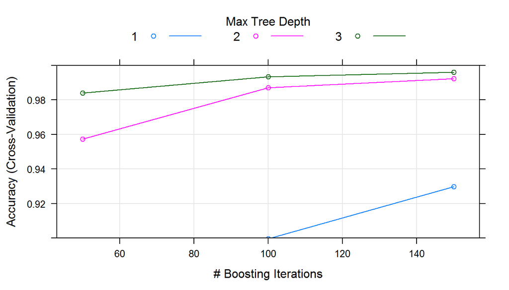

```r
plot(mod_gradientBoostR, ylim=c(0.9, 1))
```

With “Generalized Boosted Regression” method, the prediction reach an accuracy rate of **99.43**%.

## 5. Choose the best

Models accuracy :

- Decision Trees : 98.09%
- Random Forests : **99.75**%
- Generalized Boosted Regression : 99.43%

The model build on Random Forests reach the best accuracy rating with **99.75**%.

## 6. Predict classes for the testing dataset

```r
# some testing and training dataset levels type doesn't match.
# So to solve this problem we use :
for (i in 1:(length(testing)-1)) {
  levels(testing[[i]]) <- levels(pre_training[[i]])
}

prediction_RF_submit <- predict(mod_randomForest, testing[-c(58)])
testing$classe <- prediction_RF_submit
testing$classe
```

```
##  [1] B A B A A E D B A A B C B A E E A B B B
## Levels: A B C D E
```

Function to format results before submission :

```r
pml_write_files = function(x){
  n = length(x)
  for(i in 1:n){
    filename = paste0("problem_id_",i,".txt")
    write.table(x[i],file=filename,quote=FALSE,row.names=FALSE,col.names=FALSE)
  }
}

pml_write_files(prediction_RF_submit)
```